# COR 142: Exam 1 Practice Problems

**Warning**

These practice problems are not exactly the same as the questions you will see on the exam.

**Question 1**

Use the following data frame based on a sample of voters from the last student council presidential election to answer the questions below:

| **Academic Standing** | **Candidate Choice** | **Age** | **Male** |
| --- | --- | --- | --- |
| First-Year | A | 18 | 1 |
| First-Year | A | 19 | 0 |
| Second-Year | B | 20 | 1 |
| First-Year | A | 18 | 1 |
| Third-Year | B | 21 | 0 |
| Fourth-Year | B | 22 | 0 |
| Third-Year | A | 20 | 1 |

1. How many observations are there?
2. How many variables are there?
3. Which columns/variables are numerical?
4. Which columns/variables are categorical?
5. Explain the coding for the **Male** column.

**Answers**

a. There are 7 rows (not including the column headers), so there are 7 observations.  
b. There are 4 columns, so there are 4 variables.  
c. The only numerical column/variable is *Age.*  
d. The categorical columns/variables are *Academic Standing*, *Candidate Choice*, and *Male.*  
e. In the *Male* column, 1 means the student is male, and 0 means the student is not male.

**Question 2**

Suppose you were interested in determining who is likely to win a mayor’s race in St. Augustine. You select a random sample of 200 St. Augustine residents over the age of 18 and ask them who they plan to vote for. Identify the following information.

1. Population
2. Sample
3. What data was collected? Is this data numerical or categorical?

**Question 3**

Determine the following variable type.

1. Home ZIP codes of Flagler students
2. The last four digits of credit card numbers
3. Number of hours per week people spent playing video games
4. Number of cars each American household owns

**Answer**

a. Categorical  
b. Categorical  
c. Numerical  
d. Numerical

**Question 4**

Which types of plots are used for numerical variables?

**Answer**

Dotplot and histogram

**Question 5**

Which types of plots are used for categorical variables?

**Answer**

Barplot/bar chart and pie chart

**Important**

In general, if it makes sense to find the *average* of a variable, it is *numerical*. If it *does not* make sense to find the average, the variable is *categorical*.

**Question 6**

What is the name of the bar chart in which the bars are sorted from tallest to shortest?

**Answer**

Pareto chart

**Question 7**

Below is a stacked boxplot of flipper lengths for three species of penguins.

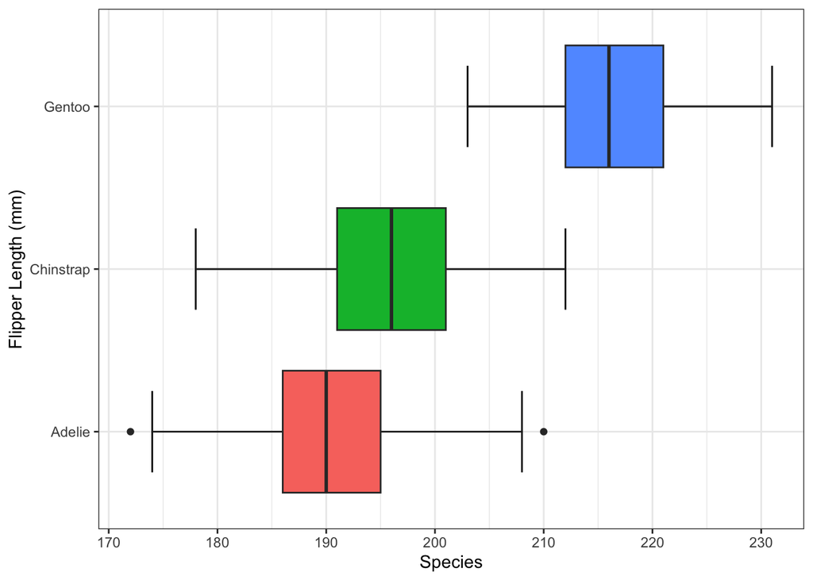

1. What is the five-number summary for the Gentoo penguins?
2. Approximately 25% of the Chinstrap penguins had flipper length greater than what value?
3. What is the approximate flipper length range for the middle 50% of the Adelie penguins?
4. Comparing all three species of penguins, which species has the greatest variation?

**Answer**

a. Minimum = 203, Q1 = 212, medium = 216, Q3 = 221, maximum = 231  
b. Q3 for Chinstrap penguins is (roughly) 201, so the approximately 25% of Chinstrap penguins had flipper length greater than 201 mm.  
c. Q1 = 186 and Q3 = 195, thus the middle 50% of the Adelie penguins have flipper lengths ranged from 186 mm to 195 mm.  
d. Without computing the IQR explicitly for each species, we can see that the IQR (the colored portion of the boxes) is roughly equal across species. So the variation of flipper length is roughly equal for all three species.

**Question 8**

A class of 52 students took a math test. Below is the test scores in relative frequencies. **Relative frequency** represents the percentage rather than the count. The number on top of a bar is the decimal form of the percentage. *Recall:* To find convert a number from its decimal form to percentage, you multiple the number by 100.

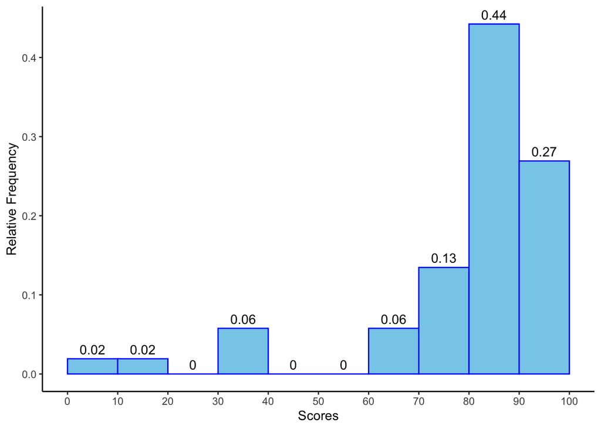

1. What type of plot is the figure above?
2. What type of distribution is the figure above?
3. What percent of students scored less than 60% on the test?
4. Approximately how many students scored a 80% or higher on the test?
5. What is the best measure of center and spread for this distribution?
6. How are the mean and median relate to each other?
7. Suppose that a test score of $69$ was mistaken recorded as $-69$, how will this affect the mean and the median?

**Answer**

a. Histogram  
b. Left-skewed  
c. $0.06 + 0.02 + 0.02 = 0.1$, so 10% of the students scored less than 60% on the test.  
d. $(0.44 + 0.27) \cdot 52 = 36.92$, so approximately 37 students had a score of 80% or above.  
e. The median and IQR are the best measure for center and spread, respectively.  
f. mean < median  
g. The mean will lower, but the median will remain the same.

**Question 9**

9. The price of 50 video game consoles were sampled. The mean price is $500 with a standard deviation of $100. Assuming that the distribution of the console prices is symmetric and unimodal.
1. Would it be reasonable to apply the empirical rule to this data? Why?
2. What does the sample mean price of $500 represent?
3. What can you say about the standard deviation of $100?
4. A used Playstation 5 is listed for $350 on eBay. Calculate and interpret its $z$-score.
5. A scalper is selling a new Nintendo Switch 2 for $700. Calculate and interpret the $z$-score.
6. What is the price range that covers 68% of the sampled data?
7. What is the price range that covers 95% of the sampled data?
8. What is the price range that covers 99.7% of the sampled data?

**Answer**

a. Because the data is symmetric and unimodal, the empirical rule applies.

c. On average, the price of a console is $100 from the mean price of $500.

d. $x = 350$, $\bar{x} = 500$, $s = 100$,
$$z = \frac{x - \bar{x}}{s} = \frac{350 - 500}{100} = \frac{-150}{100} = -1.5$$
The price of $350 is 1.5 standard deviations below the mean price of $500.

e. $x = 700$, $\bar{x} = 500$, $s = 100$,
$$z = \frac{x - \bar{x}}{s} = \frac{700 - 500}{100} = \frac{200}{100} = 2.$$
The price of $700 is 2 standard deviations above the mean price of $500.

f. According to the empirical rule, 68% of the data is within 1 standard deviation from the mean:
$$(\bar{x} - s, \bar{x} + s) = (500 - 100, 500 + 100) = (\$400, \$600)$$

g. According to the empirical rule, 95% of the data is within 2 standard deviations from the mean:
$$\begin{align}
(\bar{x} - 2s, \bar{x} + 2s)
&= (500 - 2 \cdot 100, 500 + 2 \cdot 100)\\
&= (500 - 200, 500 + 200) = (\$300, \$700)
\end{align}$$

h. According to the empirical rule, 99.7% of the data is within 3 standard deviations from the mean:
$$\begin{align}
(\bar{x} - 3s, \bar{x} + 3s) &= (500 - 3 \cdot 100, 500 + 3 \cdot 100)\\
&= (500 - 300, 500 + 300) = (\$200, \$800)
\end{align}$$

**Question 10**

The mean total SAT score in 2023 is 1028 with a standard deviation of of 221. The distribution can be approximately visualized as below.

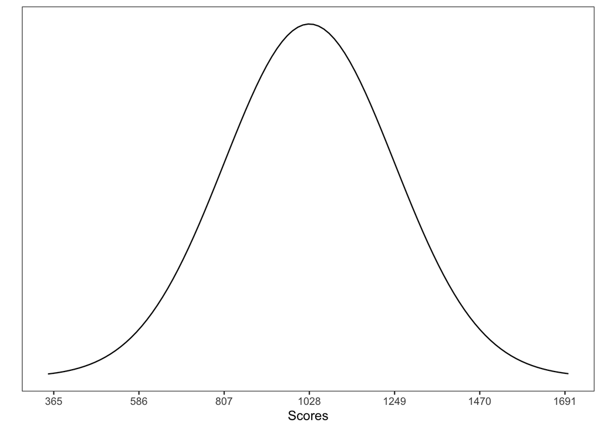

1. Approximately how many percent of all SAT scores are in the range of 807 and 1249?
2. Approximately how many percent of all SAT scores are in the range of 586 and 1470?
3. Approximately how many percent of all SAT scores are greater than 1028?
4. Approximately how many percent of all SAT scores are less 807 or greater than 1249?
5. Approximately how many percent of all SAT scores are less than 807?
6. Approximately 95% of all SAT scores are within which two scores?
7. If Amy had a score of 1300, how many standard deviations is her score above or below the mean score?

**Answer**

a. The range (807, 1249) is one standard deviation below and above the mean; by the empirical rule, approximately 68% of all scores fall within this range.

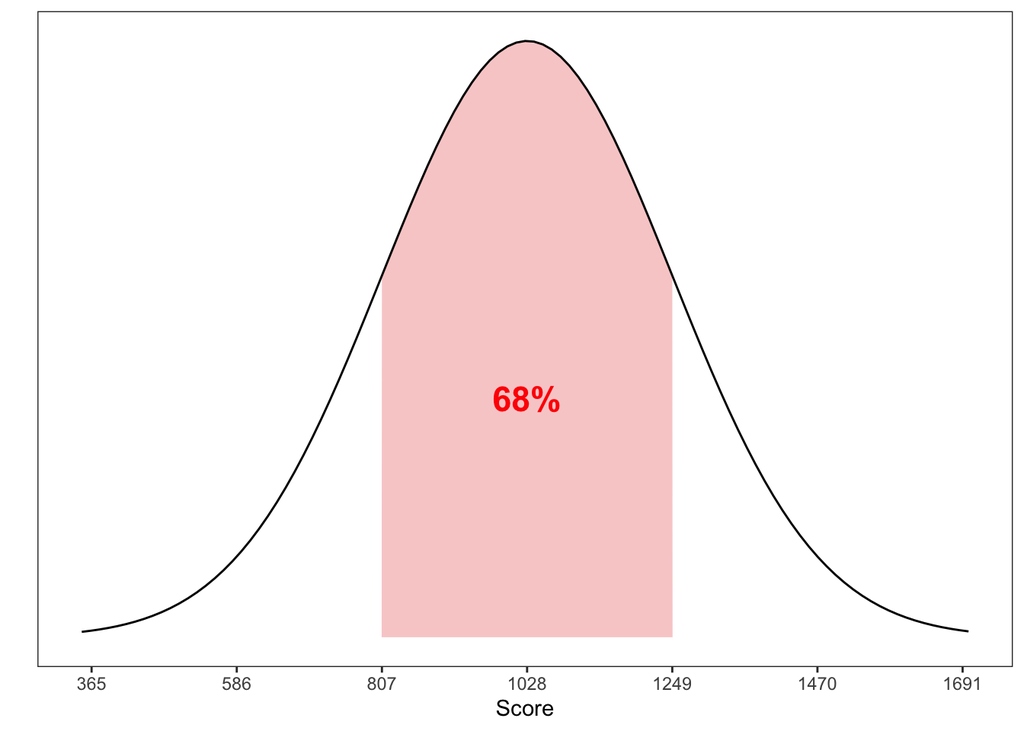

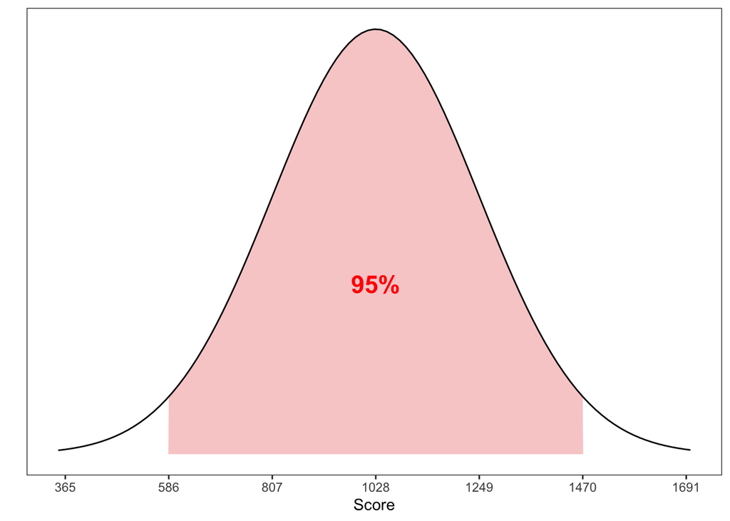

c. Since the data is unimodal and symmetric, the mean score is roughly the same as the median score, therefore, 50% of all scores are greater than 1028.

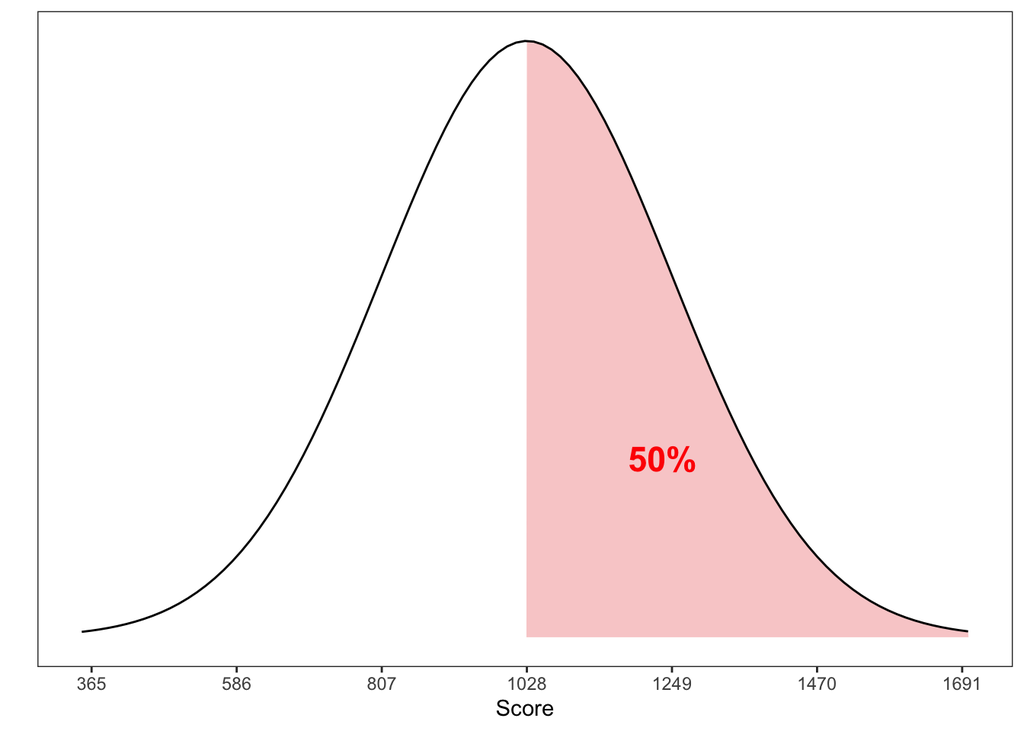

d. The regions of interest are shaded in pink. Note that these two regions are complementary to the region from part a. This means the two regions must have a combined percentage of $100 - 68 = 32\%$. Since the distribution is symmetric, the left and the right shaded regions must be equal, so each region accounts for $32/2 = 16\%$ of total scores.

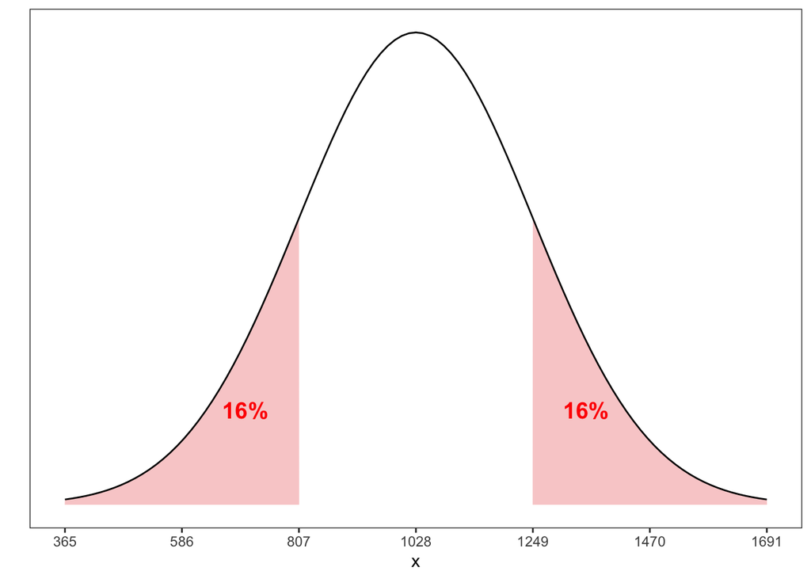

e. The region of interest in this instance is the left shaded region from part d. So approximately 16% of the total scores are less than 807.

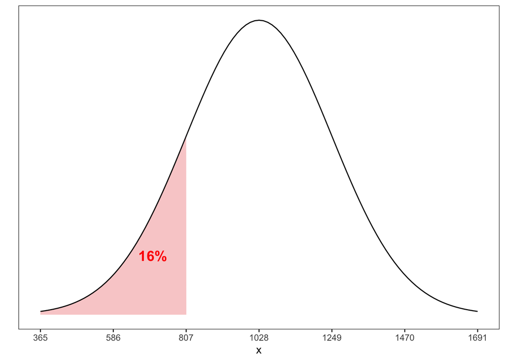

f. According to the empirical rule, approximately 95% of the data falls within 2 standard deviations from the mean, the plot is the same as that of part b. Thus the two scores are 586 and 1470.

g. We have $x = 1300$, $\bar{x} = 1028$, with $s = 221$. So the *z*-score is
$$z = \frac{x - \bar{x}}{s} = \frac{1300 - 1028}{221} \approx 1.23.$$
So Amy’s test score is roughly 1.23 standard deviations above the mean.